# Hazard Visualization, Interagency Communication, and Technical Memo Writing

Created by Madeline Brown

08/22/2022

University of California, Merced  
School of Engineering  
Spatial Analysis and Modeling (ENGR 180)

Key assignment steps are in RED

## Case Study Scenario

There is an atmospheric river event approaching the region of the Ferguson Fire, where you recently performed your landslide risk assessment. Atmospheric rivers after a wildfire are extremely dangerous for people who live, work, or travel down slope of burned hillsides.  
Read about these mudslides in a similar fire + atmospheric river scenario to understand contributing factors and resulting impacts:  
https://en.wikipedia.org/wiki/2018_Southern_California_mudflows

## Introduction

Please read all of the instructions/narrative carefully! You may feel compelled to skim to find which elements you have to satisfy to get full credit. *If you skim, you may miss key sentences and you may end up doing more work than necessary!* Also, if you have questions, give the Case Study handout a second reading. Your question is probably answered here!  
If text is in *italics*, it’s a tool or step within ArcGIS Pro.  
If text is underlined, it’s a file.

## Instructions

IMPORTANT NOTE: You will create a production quality map later in this assignment. Do not begin the Layout creation process until all of the aesthetics (e.g. labels, symbology) are how you want them! This dataset is LARGE, so if we want to make changes later on, it’s not impossible, but it may be slow/clunky.  
Later in the assignment you will write a memorandum discussing potential landslide threats to *one* (1) of the following popular tourist locations. You discovered these risks while working on the risk assessment (Lab 5-2).  
-Yosemite National Park Arch Rock Entrance  
-Hites Cove Trailhead  
-El Portal Market

### Part 1: Required Data

Utilize the LandslideRisk raster data created in Lab 5-2 to create a novel (i.e., new) visualization. Turn off any other layers you aren’t using in your *Table of Contents* to increase computing/rendering speeds.  
• Re-open your project in ArcGIS Pro for Lab 5-2.  
• Verify NED2013_mcd_albers.tif is present. If not, bring the layer in.  
• Verify LandslideRisk is present. If not, bring the layer in.

### Part 2: Communicating the Terrain

We are going to use the LandslideRisk layer for the majority of this lab, which communicates important information, but is not specific to elevation because it has been reclassified to meet different needs.

We do NOT want to use a slope layer (raster), as that would be difficult to see what’s going on with the LandslideRisk (raster).

We need to create a layer with contours (vector) based off our original DEM (from Lab 5-1).  
• *Raster Clip* LandslideRisk to the boundary of the Fire.This will greatly decrease the computing power/time needed in the remainder of the lab. Name the output ClippedLandslideRisk.  
• *Raster Clip* the original NED2013_mcd_albers.tif to the boundary of the Fire. This will greatly decrease the computing power/time needed in the remainder of the lab. Name the output ClippedNED2013.  
• Use the *Contour* geoprocessing tool on ClippedNED2013 to create 10 meter contours. We are using a relatively small contour interval since we are focusing on a smaller area of interest. Name the output LandslideContours.  
Contours should be a neutral color, but stand out clearly against the background. Remember, you are making a professional grade visualization! (e.g. no lime green, pink, purple, etc contours)

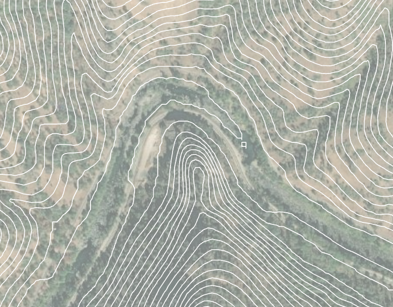

*Example Contours: Overhead View*

### Part 3: Prepping Oblique Views

As we are looking to communicate landslide data, it will be helpful for our viewers to see the area from an oblique/3-D style view.  
• Access *Insert*, *New Map*, then *New Global Scene*  
• NOTE: Be patient with Scene - this is a LOT of data and the computer may run slowly/loudly.  
• Copy and Paste your ClippedLandslideRisk and LandslideContours Layers from your main Main to your Global Scene’s *Table of Contents*. This may take a minute or two.  
• Once your layer has read in (notice it automatically is added to the 2D Layers group), you can use your mouse’s rolly button to rotate the angle of the frame, or use the navigation controls in the lower left hand corner of the frame.  
• Choose the oblique angle at which you feel like the view clearly communicates risk in a 3-dimensional view (i.e. NOT overheard, aka Nadir, view)  
• Change the transparency (*Appearance*) so the viewer can have additional location context.  
• We cannot apply labels through traditional labeling approaches in Scene to 2D objects[1]! As a work around, use the Insert - Text option to label your At Risk Site when you create your final layout.

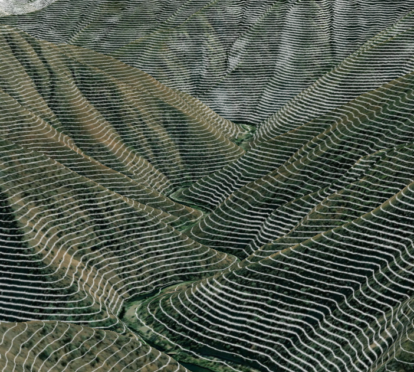

*Exaggerated Oblique View of Contours over Imagery*

### Part 4: Cross Section

A cross-section is…“a surface or shape that is or would be exposed by making a straight cut through something, especially at right angles to an axis.” - Oxford Dictionary This is another way we can visually our landslide risk and understand the topography of an area.  
To create a cross section, first access your *Map* tab with your site of choice and *only* have your NED2013 layer turned on.  
• Open the *Geoprocessing* tool *Profile*  
• Click on the pencil icon  
• Draw a line perpendicular to your area of interest. Use the green check box button to finish the line. This will add a line to your *Table of Contents*.  
• Choose the DEM resolution that corresponds with our NED2013 layer (Hint: it’s part of the spatial reference metadata)  
• Click *Run*

This will generate a new layer in your *Table of Contents* called *Output Profile.* Click on it once to highlight it.  
• Right click and select *Create Chart*  
• Select *Profile Graph*. This will generate a visual chart of the cross section you created, as demonstrated below. Yours wont match - this is a test area.  
• Use the *Export* option to export your profile as a jpg or png. You will bring this back into your final map layout shortly.

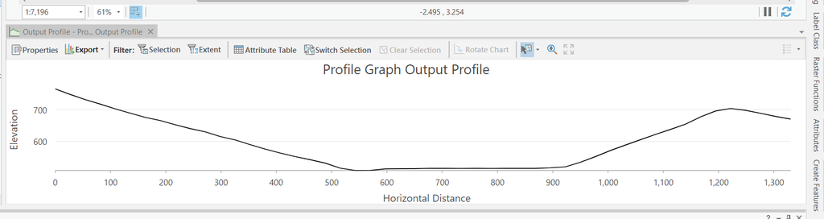

### Part 5: Production Quality Map with Multiple Frames and Inset Map

1. Main Frame Required Contents:  
   • ClippedLandslideRisk layer  
   • Your At Risk Site of choice, clearly labelled
2. Secondary Required Contents:  
   • Oblique View of At Risk Site  
   • ClippedLandslideRisk layer  
   • 10m Contours
3. Tertiary Map Required Contents:  
   • Ferguson Fire Boundary  
   • Extent indicator for your Central Frame
4. Profile Graph  
   • BONUS: Can you add a Vertical Guide to the Cross Section indicating where you At Risk Site is located? Hint: Each raster cell in NED contains elevation data.  
   Key map elements may still be required for your additional map frames if your north is rotated (must be done deliberately). Scale bars ARE required for each frame because you change the scale when you zoom in. Think carefully about how to best arrange elements. For example, the title for an inset map can be smaller and inside the map frame. This prevents it from distracting from the overall title of the map collection.  
   You are welcome to add other supplemental layers.

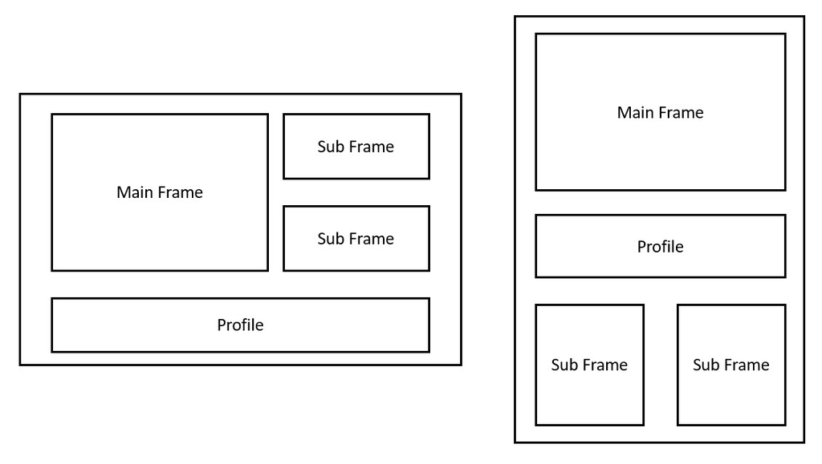

*Examples of ways to arrange your map insets. Feel free to explore other arrangements.*

### Part 7: Deliverables

At the end of this Case Study, you should have generated the following and submit in the order of MEMO first, then MAP.  
- Part 5: ONE 8.5” x 11” production quality map (portrait or landscape) containing the 4 numbered components above.  
- Part 6: ONE typed memorandum Turn in as a SINGLE pdf on Catcourses

### Part 8: References

[1]: Esri Technical Support. “Problem: Labels are not displayed in a 3D scene.” 2017. https://support.esri.com/en/technical-article/000016704